# **Final Project: R Reference Guide**

Catherine Shea

# Contents

## Loading Data and Packages

### **library()**

“library()” is a function used for loading data packages. It is regarded similarly as “require()” but functions differently when faced with referenced packages that have not yet been installed. “library()” will provide halt the code and produce an error if the data referenced is not yet installed.

> library( [package name] )

##### **Example**

```r
library(palmerpenguins)
```

Additional arguments that can be applied to the “library” function are:  
*library(package, help, pos = 2, lib.loc = NULL, character.only = FALSE, logical.return = FALSE, warn.conflicts, quietly = FALSE, verbose = getOption(“verbose”), mask.ok, exclude, include.only,attach.required = missing(include.only))*

### **require()**

“require()” is a function used for loading data packages. It is regarded similarly as “library(),” but functions differently when faced with referenced packages that have not yet been installed. “require()” acts as: ‘try to load library package’, and will provide a warning rather than an error if the data is not yet installed. This allows for code to continue to run, even after there is an error.

> require( [package name] )

##### **Example**

```r
require(here)
```

Additional arguments that can be applied to the “require” function are:  
*require(package, lib.loc = NULL, quietly = FALSE, warn.conflicts, character.only = FALSE, mask.ok, exclude, include.only, attach.required = missing(include.only))*

### **here()**

“here()” is a function imported from the “here” package that allows for RStudio to locate project files based off of one’s current working directory. Prior to use of this function for the first time, import this package using:

> install.packages(“here”)

> require(here)

> [variable] = read.csv(here(“[folder containing csv]”, “[csv file name].csv”))

##### **Example**

```r
ginkgo = data.frame(read.csv(here("environmental_data","data", "ginkgo_data_2022.csv")))
```

This example implements the “read.csv()” and “data.frame()” functions, in addition to “here()”. Details regarding the extra functions can be found in *Loading Data and Packages* and *Data Structures.*

### **read.csv()**

“read.csv()” extracts data from a csv file, allowing RStudio to use and manipulate the dataset inside of the file. It is used in conjunction with the “here” package to import the data, and is formatted as such:

> [variable] = read.csv(here(“[folder containing csv]”, “[csv file name].csv”))

##### **Example**

```r
ginkgo = data.frame(read.csv(here("environmental_data","data", "ginkgo_data_2022.csv")))
```

This example implements the “here()” and “data.frame()” functions, in addition to “read.csv()”. Details regarding the extra functions can be found in *Loading Data and Packages* and *Data Structures.*

Additional arguments that can be applied to the “read.csv” tool are:  
*read.csv(file, header = TRUE, sep = “,”, quote = ” ” “, decimal =”.”, fill = TRUE, comment.char = ” “, …)*

back to top  
:)

## Data Structures

### **c()**

The function c() combines or concatenates its arguments into a vector (a 1-dimensional data structure consisting of 1 or more elements). All of the elements must be of the same type—it is not possible to combine string characters and numeric values together.

> c(a, b, c, x, …)

##### **Example**

```r
number_vec = c(1, 4, 8, 9, 13)
character_vec = c("a", "fish", "data is cool")
number_vec
```

```
## [1]  1  4  8  9 13
```

```r
print(character_vec)
```

```
## [1] "a"            "fish"         "data is cool"
```

### **length()**

The function “length()” obtains the length of vector/list components, a.k.a, the number of features within a vector/list.

> variable = length(x)

##### **Example**

```r
gink_petiole_len = length(unique(ginkgo$petiole_length))

gink_petiole_len
```

```
## [1] 82
```

This example implements the “unique()” functions in addition to “length(),” of which is useful in extracting non-repeating numeric or character values from a vector.

### **matrix()**

The ’matrix()” function produces a matrix from a set of data values, derived from individually-mentioned values, a list, or vector.

> matrix([data], [number of rows], [number of columns], [organize by row - True/False]…)

##### **Example**

```r
num_matrix = matrix(c(1,2,3,4, 5,6,7,8), nrow = 4, byrow = TRUE)

num_matrix
```

```
##      [,1] [,2]
## [1,]    1    2
## [2,]    3    4
## [3,]    5    6
## [4,]    7    8
```

Additional arguments that can be applied to the “matrix” function are:  
*matrix(data = NA, nrow = 1, ncol = 1, byrow = FALSE, dimnames = NULL)*

### **data.frame()**

“data.frame()” creates a data frame, of which is a list of variables with unique row names that create ‘classes’. Data frames behave similarly to lists and matrices, and are crucial to data manipulation and analysis in R.

> data.frame(…), where ‘…’ is a variable, concatenation, or manually listed values.

##### **Example**

```r
ginkgo = data.frame(read.csv(here("environmental_data","data", "ginkgo_data_2022.csv")))
```

This example implements the “here()” and “read.csv()” functions, in addition to “data.frame()”. Details regarding the extra functions can be found in *Loading Data and Packages.*

Additional arguments that can be applied to the “data.frame” function are:  
*data.frame(…, row.names = NULL, check.rows = FALSE, check.names = TRUE, fix.empty.names = TRUE, stringsAsFactors = FALSE)*

### **nrow()**

“nrow()” retrieves the number of rows present within a specified dataset: ( vector, list, data frame… )

> num_rows = nrow(x)

##### **Example**

```r
nrow(ginkgo)
```

```
## [1] 220
```

### **ncol()**

“ncol()” retrieves the number of columns present within a specified dataset: ( vector, list, data frame… )

> num_column = ncol(x)

##### **Example**

```r
ncol(ginkgo)
```

```
## [1] 6
```

### **dim()**

“dim()” retrieves the dimensions of a specified dataset:( vector, list, data frame… )

> dim(x)

##### **Example**

```r
dim(ginkgo)
```

```
## [1] 220   6
```

back to top  
:)

## Subsetting

### **$**

The dollar sign acts as a subset to a database in order to refer to a specific column when performing analyses. It is formatted as so that the parent dataset name is written, then the dollar sign, and then the specified column is written. This format relies on attribute-based extraction of information.

> dat_attribute = [dataset]$[attribute]

##### **Example**

```r
ginkgo$petiole_length
```

```
##   [1]  91  56  71  44  40  50  82  84  70  40  70  88  43  59  42  49  71  85
##  [19]  35  75  54  50  33  36  42  31  67  54  71  71  36  22  47  37  58  25
##  [37]  60  65  45  48  82  63  97  81  70  70  75  54  60  37  33  57 100  32
##  [55]  76  25  50  43  79  93  90  75  36  36  45  76  32  62  69  49  58  71
##  [73]  54  49  55  84  69  73  62  45  62  50  30  80  58  50  65  56  50  53
##  [91]  58  71 100  86 102  73  71  83  84  77  65 100  54  51  70  53  62  61
## [109]  72 103 106  85  92 114  82  92 126 104  96  52  51  53  57  46  69  57
## [127]  41  58  77  55  67  42  75  50  76  60  71  64  58  55  45  79  62  39
## [145]  50  39  53  62  45  40  26  79  38  53  50  51  59  30  63  65  41  53
## [163]  56  58  45  67  53  32  50  69  45  72  55  27  62  76  41  37  43  57
## [181]  51  63  68  66  46  93  52  48  69  68  70  61  25  21  30  25  43  18
## [199]  30  13  62  28  67  75  68  86  55  94  79  19  61  22  23  73  70  14
## [217]  69 113 111  31
```

### **[ ]**

The square brackets “[ ]” act as a subset to a database based on position within a data frame. It is formatted as so that the parent dataset name is written, and then the brackets with i, j coordinates are attached.

> x[i, j]

##### **Example**

```r
ginkgo[1,]
```

```
##   site_id seeds_present max_width max_depth notch_depth petiole_length
## 1     216         FALSE        85        59          12             91
```

```r
ginkgo[2,3]
```

```
## [1] 72
```

```r
ginkgo[,3] #select the third column
```

```
##   [1]  85  72  64  76  85  75  72  81  87  87  94  92  70  84  61 102  82  64
##  [19]  53  66  69  55  56  64  60  59  57  53  68  56  75  63  82  83  60  67
##  [37]  75  92 110  54  77  59  51 100  92  77  99  62  80  86  63  79  91  72
##  [55]  64  53  71  61  70  93  75  87  86  87  95  88  85  95  95  52  84  74
##  [73]  87  76  57  92  94  79  97  50 100  97  63  96  97  70  83  80  85 100
##  [91] 112 115  83 106  95  80 120  76  50  90  94  69  93  59  60 103  95  90
## [109]  80  90 106  98  73  89  65  83 116  90  86 104  92 103 100  91 102  99
## [127]  98 104  80  68  62  77  86  72  70  63  72  65  69  67  35  67  63  71
## [145]  77  60  70  69  55  72  84 106  61 114  95  86  60  78  86  91  79  95
## [163]  72 102  72 107  95  91  94  90  98  63  58  67  92  75  74  73  73  94
## [181]  76  86  78  74  89  77  80  71  69  81  39  60  50  47  52  61  56  45
## [199]  64  42 103  84 118 120 100 111 104  94  78  70  92  48  79  91 111  44
## [217] 117  93 101 145
```

### **subset()**

“subset()” creates a subset of a dataset through use of a conditional. While the ‘$’ is based on column names and the ‘[ ]’ is based on extracting data positions, this function allows one to extract information based on whether specific parameters are met.

> subset(x, …)

##### **Example**

```r
dat_ade = droplevels(subset(penguins, species == "Adelie", na.rm = TRUE))
dat_ade
```

```
## # A tibble: 152 × 8
##    species island    bill_length_mm bill_depth_mm flipper_…¹ body_…² sex    year
##    <fct>   <fct>              <dbl>         <dbl>      <int>   <int> <fct> <int>
##  1 Adelie  Torgersen           39.1          18.7        181    3750 male   2007
##  2 Adelie  Torgersen           39.5          17.4        186    3800 fema…  2007
##  3 Adelie  Torgersen           40.3          18          195    3250 fema…  2007
##  4 Adelie  Torgersen           NA            NA           NA      NA <NA>   2007
##  5 Adelie  Torgersen           36.7          19.3        193    3450 fema…  2007
##  6 Adelie  Torgersen           39.3          20.6        190    3650 male   2007
##  7 Adelie  Torgersen           38.9          17.8        181    3625 fema…  2007
##  8 Adelie  Torgersen           39.2          19.6        195    4675 male   2007
##  9 Adelie  Torgersen           34.1          18.1        193    3475 <NA>   2007
## 10 Adelie  Torgersen           42            20.2        190    4250 <NA>   2007
## # … with 142 more rows, and abbreviated variable names ¹flipper_length_mm,
## #   ²body_mass_g
```

back to top

## Numerical Data Exploration

### **summary()**

The “summary()” function produces summary results for a dataset. It provides information on mean, median, 1st quarter, 3rd quarter, minimum, and maximum values.

> summary(object, …)

##### **Example**

```r
summary(ginkgo$notch_depth)
```

```
##    Min. 1st Qu.  Median    Mean 3rd Qu.    Max.
##   0.000   0.000   2.000   5.977   6.250  92.000
```

### **mean()**

“mean()” calculates the average value for an inserted dataset, list, or vector.

> mean(x, …)

##### **Example**

```r
mean(ginkgo$max_width)
```

```
## [1] 79.95455
```

### **sd()**

“sd()” calculates the standard deviation (variance) of the specified dataset, vector, or list.

> sd(x, na.rm = FALSE) #na.rm indicates whether missing values should be removed.

##### **Example**

```r
sd(ginkgo$max_depth)
```

```
## [1] 12.7281
```

back to top :)

## Graphical Data Exploration

### **plot()**

The “plot()” function creates a scatter plot based off of input ‘x’ and ‘y’ values.

> plot(x ~ y, …)

##### **Example**

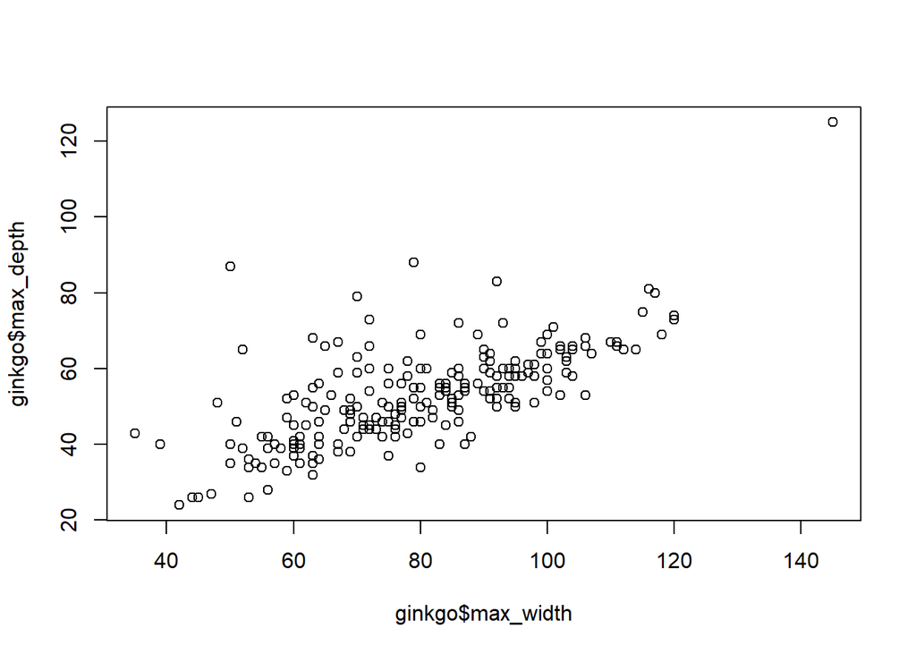

```r
plot(ginkgo$max_depth ~ ginkgo$max_width)
```

Additionally, the visual format of a plot can be set through setting a “type =”. Type p, (Points) is the default setting.

The type options are:

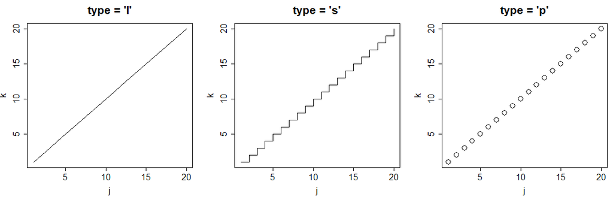

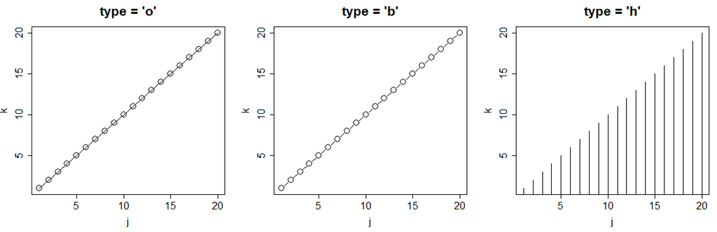

There are additional parameters that can be added to the function in order to alter visual formatting of the plot, including: *‘col’, ‘pch’, ‘main’, ‘sub’, ‘type’, ‘cex’, ‘xlab’, ‘ylab’, ‘xlim’, ylim’….*  
Details on inclusion of these parameters are presented in the tabs below.

#### **col =**

“col =” refers to designation of the data point border-color within the plot.

> The colors can be assigned through:  
> - common color terminology -> *col = “red”*  
> - number values 1-8 -> *col = 3*  
> - hexadecimal values -> *col = #000FF*  
> - RGB value format – through use of the “rgb()” function -> *col = rgb(0,1,1)*

##### **Example**

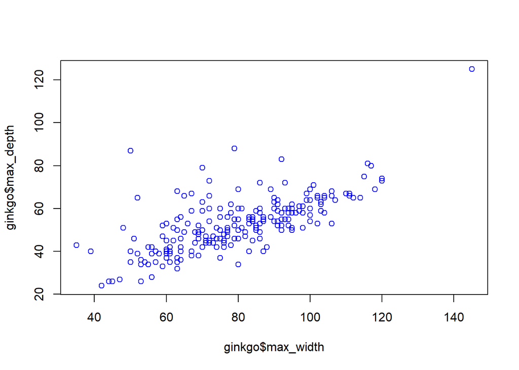

```r
plot(ginkgo$max_depth ~ ginkgo$max_width, col = "blue")
```

#### **pch =**

“pch =” is a parameter option in the plot function that allows one to change the shape of the data points. Designation of the pch value is set through assigning a value 1-25, of which correspond to the features below:

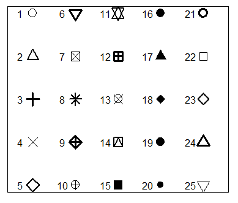

> plot(x, y, pch = [1 through 25])

##### **Example**

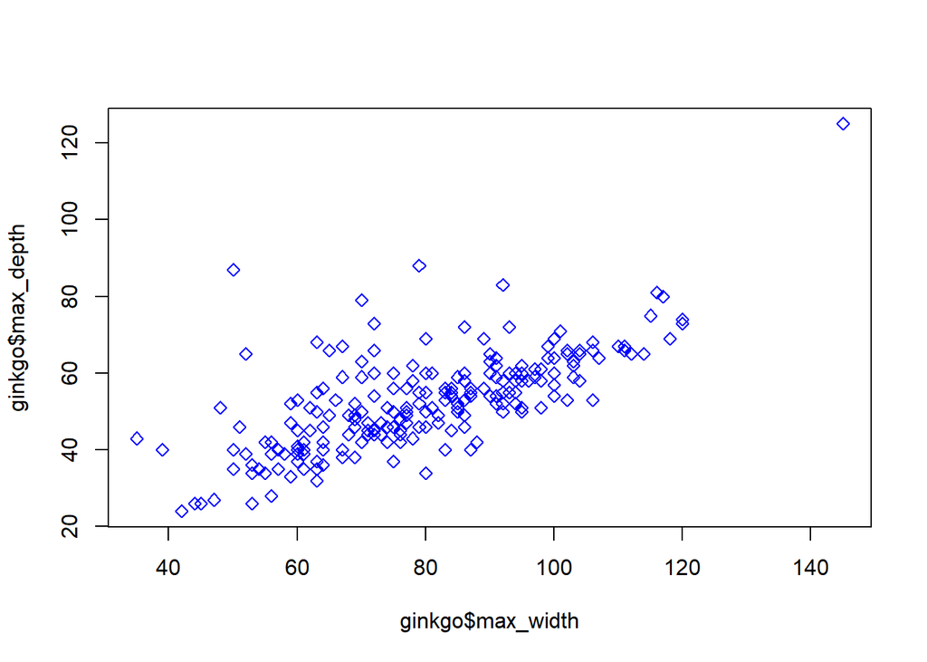

```r
plot(ginkgo$max_depth ~ ginkgo$max_width, col = "blue", pch = 23)
```

#### **cex =**

“cex =” determines the size of the data points in the plot.

> plot(x, y, cex = 0.5) plot(x, y, cex = 2)

##### **Example**

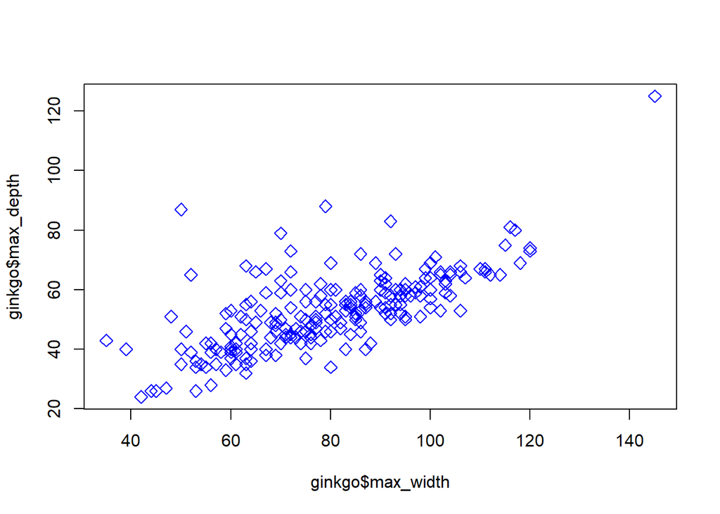

```r
plot(ginkgo$max_depth ~ ginkgo$max_width, col = "blue", pch = 23, cex = 1.3)
```

cex can also be applied to the label-editors: main, sub, lab, and axis (Formatted as: cex.main = ).

#### **main =**

“main =” assigns a primary title to a plot. The title must be surrounded by quotations for appropriate use of the parameter.

> plot(x, y, main = “[text]”)

##### **Example**

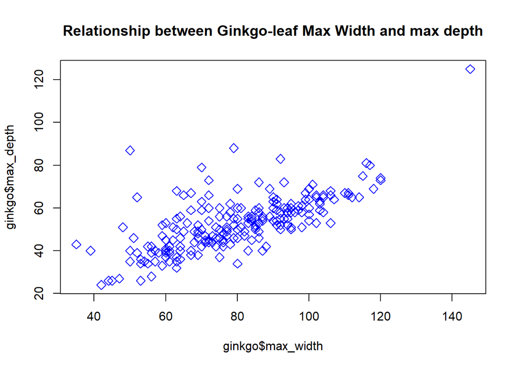

```r
plot(ginkgo$max_depth ~ ginkgo$max_width, main = "Relationship between Ginkgo-leaf Max Width and max depth", col = "blue", pch = 23, cex = 1.3)
```

A secondary sub-title can be assigned to the plot, using sub = ” “.

#### **xlab =**

“xlab =” allows for editing of the X axis title. The appended title must be held in quotations.

> plot(x, y, xlab = “[text]”)

##### **Example**

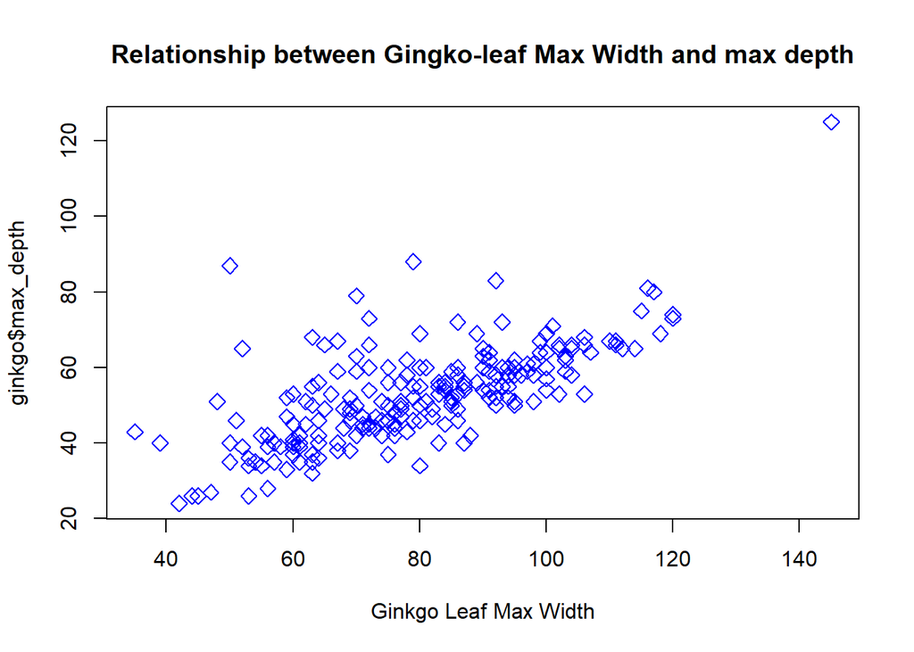

```r
plot(ginkgo$max_depth ~ ginkgo$max_width, main = "Relationship between Gingko-leaf Max Width and max depth", xlab = "Ginkgo Leaf Max Width", col = "blue", pch = 23, cex = 1.3)
```

#### **ylab =**

“ylab =” allows for editing of the y axis title. The appended title must be held in quotations.

> plot(x, y, ylab = “[text]”)

##### **Example**

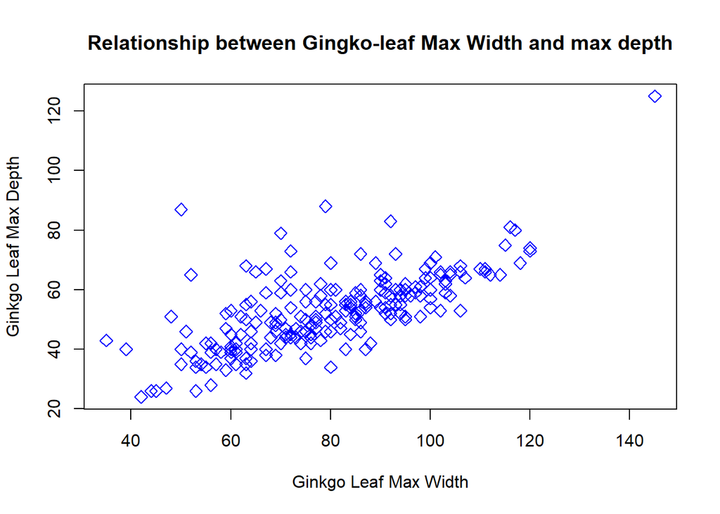

```r
plot(ginkgo$max_depth ~ ginkgo$max_width, main = "Relationship between Gingko-leaf Max Width and max depth", xlab = "Ginkgo Leaf Max Width", ylab = "Ginkgo Leaf Max Depth", col = "blue", pch = 23, cex = 1.3)
```

#### **xlim =**

“xlim =” creates alterations to plot’s x-axis dimensions, applying the c() function to provide the x-axis minimum and maximum values.

> plot(x, y, xlim = c([min],[max]))

##### **Example**

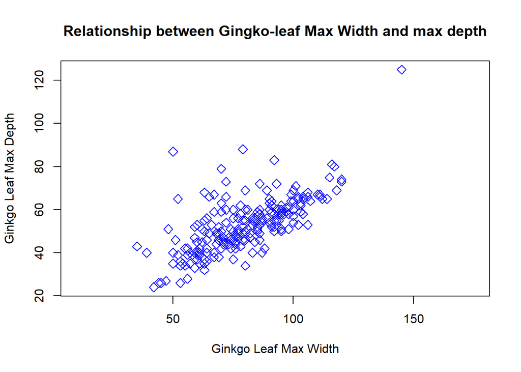

```r
plot(ginkgo$max_depth ~ ginkgo$max_width, main = "Relationship between Gingko-leaf Max Width and max depth", xlab = "Ginkgo Leaf Max Width", ylab = "Ginkgo Leaf Max Depth", xlim = c(10,175), col = "blue", pch = 23, cex = 1.3)
```

#### **ylim =**

“ylim =” creates alterations to plot’s y-axis dimensions, applying the c() function to provide the y-axis minimum and maximum values.

> plot(x, y, ylim = c([min],[max]))

##### **Example**

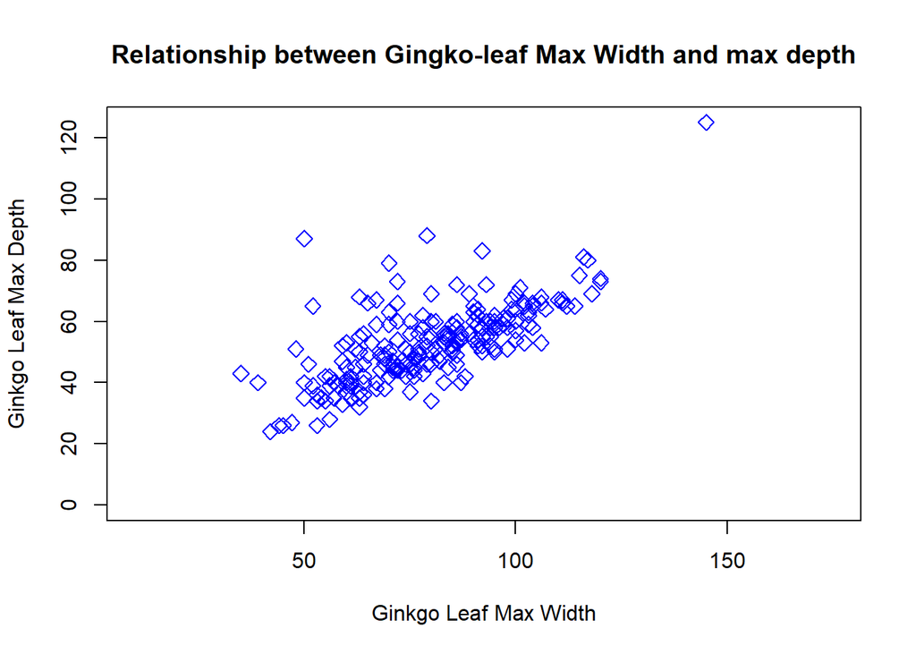

```r
plot(ginkgo$max_depth ~ ginkgo$max_width, main = "Relationship between Gingko-leaf Max Width and max depth", xlab = "Ginkgo Leaf Max Width", ylab = "Ginkgo Leaf Max Depth", xlim = c(10,175), ylim = c(0, 125), col = "blue", pch = 23, cex = 1.3)
```